# Lab 8

Author

Ryan Fernald

Remember, **follow the instructions below and use R Markdown to create a pdf document with your code and answers to the following questions on Gradescope.** You may find a template file by clicking “Code” in the top right corner of this page.

## A. Bootstrapping the sampling distribution of the median

1. Using the `penguins` dataset in the `palmerpenguins` package, construct a confidence interval for the mean `body_mass_g` for female Adelie penguins based on using a normal distribution based on the central limit theorem. You should compute the confidence interval without using `confint()`.

```r
library(palmerpenguins)
library(tidyverse)
data(penguins)
head(penguins)
```

```
# A tibble: 6 × 8
  species island    bill_length_mm bill_depth_mm flipper_length_mm body_mass_g
  <fct>   <fct>              <dbl>         <dbl>             <int>       <int>
1 Adelie  Torgersen           39.1          18.7               181        3750
2 Adelie  Torgersen           39.5          17.4               186        3800
3 Adelie  Torgersen           40.3          18                 195        3250
4 Adelie  Torgersen           NA            NA                  NA          NA
5 Adelie  Torgersen           36.7          19.3               193        3450
6 Adelie  Torgersen           39.3          20.6               190        3650
# ℹ 2 more variables: sex <fct>, year <int>
```

```r
female_penguins <- penguins |>
  filter(species == 'Adelie', sex == 'female')
head(female_penguins)
```

```
# A tibble: 6 × 8
  species island    bill_length_mm bill_depth_mm flipper_length_mm body_mass_g
  <fct>   <fct>              <dbl>         <dbl>             <int>       <int>
1 Adelie  Torgersen           39.5          17.4               186        3800
2 Adelie  Torgersen           40.3          18                 195        3250
3 Adelie  Torgersen           36.7          19.3               193        3450
4 Adelie  Torgersen           38.9          17.8               181        3625
5 Adelie  Torgersen           41.1          17.6               182        3200
6 Adelie  Torgersen           36.6          17.8               185        3700
# ℹ 2 more variables: sex <fct>, year <int>
```

```r
mean_bm <- mean(female_penguins$body_mass_g)
sd_bm <- sd(female_penguins$body_mass_g)
```

```r
z <- qnorm(1 - 0.05/2)

ci_variance <- z * ( sd_bm / sqrt(length(female_penguins$body_mass_g)))

low_ci <- mean_bm - ci_variance
high_ci <- mean_bm + ci_variance

ci <- c(low_ci, high_ci)

cat("low ci:", ci[1], "     high ci:", ci[2])
```

```
low ci: 3307.041      high ci: 3430.63
```

2. Construct a bootstrap confidence interval for the mean `body_mass_g` for female Adelie penguins using 10000 resamples.

```r
bs_ci <- replicate(10000, mean(sample(female_penguins$body_mass_g, replace = TRUE)))

quantile(bs_ci, probs = c(.025, .975))
```

```
    2.5%    97.5%
3305.822 3430.137
```

3. Construct a bootstrap confidence interval for the median `body_mass_g` for female Adelie penguins using 10000 resamples.

```r
bs_ci_median <- replicate(10000, median(sample(female_penguins$body_mass_g, replace = TRUE)))

quantile(bs_ci_median, probs = c(.025, .975))
```

```
 2.5% 97.5%
 3300  3450
```

## B. Simulations

4. Suppose that $Y\sim \mathrm{Poisson}(X)$ where $X\sim \mathrm{Exponential}(1)$. Use simulation to estimate $E(Y)$ and $\mathrm{Var}(Y)$.

```r
simulate_Y <- replicate(10000, {
  X <- rexp(1, rate = 1)
  Y <- rpois(1, lambda = X)
  return(Y)
})

E_Y <- mean(simulate_Y)
Var_Y <- var(simulate_Y)

cat("Estimate of E(Y) from simulation:", E_Y, "\n")
```

```
Estimate of E(Y) from simulation: 0.983
```

```r
cat("Estimate of Var(Y) from simulation:", Var_Y)
```

```
Estimate of Var(Y) from simulation: 1.935905
```

5. For this question, you will write a simulation to test the frequentist coverage of a 95% confidence interval for a proportion based on the normal approximation.
   1. First, write a function that takes two inputs: `n` and `p`. Your function should randomly generate some $X\sim \mathrm{Binomial}(n, p)$, compute $\widehat{p}= X/n$, and then compute the corresponding normal distribution-based confidence interval for $p$ **based on your sample** $\widehat{p}$. Your function should return `TRUE` if $p$ is in the confidence interval. You may use the following formula for the confidence interval:

   $$\widehat{p}\pm z_{.975}\sqrt{\frac{\widehat{p}(1-\widehat{p})}{n}}$$

```r
frequentist_coverage <- function(n, p) {

  X <- rbinom(1, n, p)

  p_hat <- X/n

  standard_error <- sqrt(p_hat * (1-p_hat) / n)

  lower_bound <- p_hat - qnorm(.975) * standard_error
  upper_bound <- p_hat + qnorm(.975) * standard_error

  return(lower_bound <= p && upper_bound >= p)
}
```

[output not shown]

```r
coverage_simulation <- function(n, p, n_runs) {

  coverage_portion <- mean(replicate(n_runs, frequentist_coverage(n, p)))

  return(coverage_portion)
}
```

```
c.  Test your function from (b) with `n = 20`, `p = .5`, and `n_runs = 1000`.
```

```r
coverage_simulation(n_runs = 1000, n = 20, p = .5)
```

```
[1] 0.966
```

```
d.  Use your simulation code to investigate the following questions: For what values of `n` and `p` is the frequentist coverage close to the expected 95% value? For what values of `n` and `p` is the frequentist coverage very different to the expected 95% value?
```

```r
coverage_simulation(n_runs = 10, n = 5, p = .5)
```

```
[1] 0.9
```

```r
coverage_simulation(n_runs = 1000, n = 5, p = .5)
```

```
[1] 0.95
```

```r
coverage_simulation(n_runs = 20, n = 500, p = .5)
```

```
[1] 0.9
```

```r
coverage_simulation(n_runs = 1000000, n = 10000, p = .5)
```

```
[1] 0.948905
```

When I have significantly large enough number of runs or a significanyly large enough n, the coverage is closest to it’s expected 95% value.

## C. Hypothesis Testing

Use the following code to obtain the Hawaiian Airlines and Alaska Airlines flights from the `nycflights13` package.

```r
library(tidyverse)
library(nycflights13)
data("flights")
flights_sample <- flights |>
  filter(carrier %in% c("HA", "AS"))
head(flights_sample)
```

```
# A tibble: 6 × 19
   year month   day dep_time sched_dep_time dep_delay arr_time sched_arr_time
  <int> <int> <int>    <int>          <int>     <dbl>    <int>          <int>
1  2013     1     1      724            725        -1     1020           1030
2  2013     1     1      857            900        -3     1516           1530
3  2013     1     1     1808           1815        -7     2111           2130
4  2013     1     2      722            725        -3      949           1030
5  2013     1     2      909            900         9     1525           1530
6  2013     1     2     1818           1815         3     2131           2130
# ℹ 11 more variables: arr_delay <dbl>, carrier <chr>, flight <int>,
#   tailnum <chr>, origin <chr>, dest <chr>, air_time <dbl>, distance <dbl>,
#   hour <dbl>, minute <dbl>, time_hour <dttm>
```

6. Compute a 95% confidence interval for the mean `arr_delay` for Alaska Airlines flights. Interpret your results.

```r
alaska_flights_sample <- flights_sample |>
  filter(carrier == "AS")
head(alaska_flights_sample)
```

```
# A tibble: 6 × 19
   year month   day dep_time sched_dep_time dep_delay arr_time sched_arr_time
  <int> <int> <int>    <int>          <int>     <dbl>    <int>          <int>
1  2013     1     1      724            725        -1     1020           1030
2  2013     1     1     1808           1815        -7     2111           2130
3  2013     1     2      722            725        -3      949           1030
4  2013     1     2     1818           1815         3     2131           2130
5  2013     1     3      724            725        -1     1012           1030
6  2013     1     3     1817           1815         2     2121           2130
# ℹ 11 more variables: arr_delay <dbl>, carrier <chr>, flight <int>,
#   tailnum <chr>, origin <chr>, dest <chr>, air_time <dbl>, distance <dbl>,
#   hour <dbl>, minute <dbl>, time_hour <dttm>
```

```r
mean_ak_arr_delay <- mean(alaska_flights_sample$arr_delay, na.rm = TRUE)
sd_ak_arr_delay <- sd(alaska_flights_sample$arr_delay, na.rm = TRUE)
```

```r
z <- qnorm(1 - 0.05/2)

ci_variance <- z * ( sd_ak_arr_delay / sqrt(length(alaska_flights_sample$arr_delay)))

low_ci_ak <- mean_ak_arr_delay - ci_variance
high_ci_ak <- mean_ak_arr_delay + ci_variance

ci_ak <- c(low_ci_ak, high_ci_ak)

cat("low ci:", ci_ak[1], "     high ci:", ci_ak[2])
```

```
low ci: -12.60688      high ci: -7.254894
```

The low end of the confidence interval is -12, while the high for the confidence interval is -7. Meaning that the average arrival delay for flights on Alaskan airlines are statistically better, or “less delayed” than other flights.

7. Compute a 95% confidence interval for the mean `arr_delay` for Hawaiian Airlines flights. Interpret your results.

```r
hawaii_flights_sample <- flights_sample |>
  filter(carrier == "HA")
head(hawaii_flights_sample)
```

```
# A tibble: 6 × 19
   year month   day dep_time sched_dep_time dep_delay arr_time sched_arr_time
  <int> <int> <int>    <int>          <int>     <dbl>    <int>          <int>
1  2013     1     1      857            900        -3     1516           1530
2  2013     1     2      909            900         9     1525           1530
3  2013     1     3      914            900        14     1504           1530
4  2013     1     4      900            900         0     1516           1530
5  2013     1     5      858            900        -2     1519           1530
6  2013     1     6     1019            900        79     1558           1530
# ℹ 11 more variables: arr_delay <dbl>, carrier <chr>, flight <int>,
#   tailnum <chr>, origin <chr>, dest <chr>, air_time <dbl>, distance <dbl>,
#   hour <dbl>, minute <dbl>, time_hour <dttm>
```

```r
mean_ha_arr_delay <- mean(hawaii_flights_sample$arr_delay, na.rm = TRUE)
sd_ha_arr_delay <- sd(hawaii_flights_sample$arr_delay, na.rm = TRUE)
```

```r
z <- qnorm(1 - 0.05/2)

ci_variance <- z * ( sd_ha_arr_delay / sqrt(length(hawaii_flights_sample$arr_delay)))

low_ci_ak <- mean_ha_arr_delay - ci_variance
high_ci_ak <- mean_ha_arr_delay + ci_variance

ci_ak <- c(low_ci_ak, high_ci_ak)

cat("low ci:", ci_ak[1], "     high ci:", ci_ak[2])
```

```
low ci: -14.87762      high ci: 1.047215
```

The confidence interval for hawaiian airlines flights’ arrival delays has a low bound to the confidence interval of -14, and a high of 1.0, this is a wider interval compared to the Alaskan airlines.

8. Compute a 95% confidence interval for the proportion of flights for which `arr_delay > 0` for Hawaiian Airlines flights. Interpret your results.

```r
hawaii_flights_sample <- flights_sample |>
  filter(carrier == "HA", arr_delay > 0)

mean_ha_arr_delay <- mean(hawaii_flights_sample$arr_delay, na.rm = TRUE)
sd_ha_arr_delay <- sd(hawaii_flights_sample$arr_delay, na.rm = TRUE)

z <- qnorm(1 - 0.05/2)

ci_variance <- z * ( sd_ha_arr_delay / sqrt(length(hawaii_flights_sample$arr_delay)))

low_ci_ak <- mean_ha_arr_delay - ci_variance
high_ci_ak <- mean_ha_arr_delay + ci_variance

ci_ak <- c(low_ci_ak, high_ci_ak)

cat("low ci:", ci_ak[1], "     high ci:", ci_ak[2])
```

```
low ci: 9.150284      high ci: 60.91157
```

The arrival delay for the portion of Hawaiian airlines flights arrival delay > 0, is very wide with a lower bound of 9 and a upper bound of 61, which is over an hour. So while the mean of all flight delays coming from Hawaiian airlines, is better than the average of all airlines, it is still fairly bad because of the inconsistency in the range of time to which the flight arrival can be delayed.

9. Consider the null hypothesis that the mean `arr_delay` for Alaska is equal to the mean `arr_delay` for Hawaiian and the alternative hypothesis that the mean `arr_delay` values are different for the two airlines. Perform an appropriate hypothesis test and interpret your results.

```r
#H_0 is that arr_delay HA == arr_delay AS
#H_A is that this^ =/=

hawaii_flights <- flights_sample |>
  filter(carrier == "HA")
alaska_sample <- flights_sample |>
  filter(carrier == "AS")

t_test_result <- t.test(alaska_sample$arr_delay, hawaii_flights$arr_delay)
t_test_result
```

```
    Welch Two Sample t-test

data:  alaska_sample$arr_delay and hawaii_flights$arr_delay
t = -0.70339, df = 420.37, p-value = 0.4822
alternative hypothesis: true difference in means is not equal to 0
95 percent confidence interval:
 -11.443017   5.411649
sample estimates:
mean of x mean of y
-9.930889 -6.915205
```

the p-value is not low enough for us to reject the null hypothesis, so therefore we say, there is insufficient data to reject the null hypothesis. Meaning there is not a statistically difference between the mean arrival delay between alaska and hawaii airlines.

## D. Linear Regression

Researchers at the University of Texas in Austin, Texas tried to figure out what causes differences in instructor teaching evaluation scores. Use the following code to load data on 463 courses. A full description of the data can be found [here](https://www.openintro.org/book/statdata/?data=evals).

```r
evals <- readr::read_csv("https://www.openintro.org/book/statdata/evals.csv")
head(evals)
```

```
# A tibble: 6 × 21
  score rank         ethnicity  gender language   age cls_perc_eval cls_did_eval
  <dbl> <chr>        <chr>      <chr>  <chr>    <dbl>         <dbl>        <dbl>
1   4.7 tenure track minority   female english     36          55.8           24
2   4.1 tenure track minority   female english     36          68.8           86
3   3.9 tenure track minority   female english     36          60.8           76
4   4.8 tenure track minority   female english     36          62.6           77
5   4.6 tenured      not minor… male   english     59          85             17
6   4.3 tenured      not minor… male   english     59          87.5           35
# ℹ 13 more variables: cls_students <dbl>, cls_level <chr>, cls_profs <chr>,
#   cls_credits <chr>, bty_f1lower <dbl>, bty_f1upper <dbl>, bty_f2upper <dbl>,
#   bty_m1lower <dbl>, bty_m1upper <dbl>, bty_m2upper <dbl>, bty_avg <dbl>,
#   pic_outfit <chr>, pic_color <chr>
```

10. Carry out a linear regression with `score` as the response variable and `age` as the single explanatory variable. Interpret your results.

```r
linear_regression_score_age <- lm(score ~ age, data = evals)
linear_regression_score_age
```

```
Call:
lm(formula = score ~ age, data = evals)

Coefficients:
(Intercept)          age
   4.461932    -0.005938
```

There is a slight negative correlation between age and scores, with a regression line $\beta_1$ is -0.005938, and $\beta_0$ is 4.4, meaning when age is 0 the score is 4.4, which is not reasonable.

11. Extend your regression model by adding an additional explanatory variable. What happens to your results? Are the new $p$-values appropriate to use?

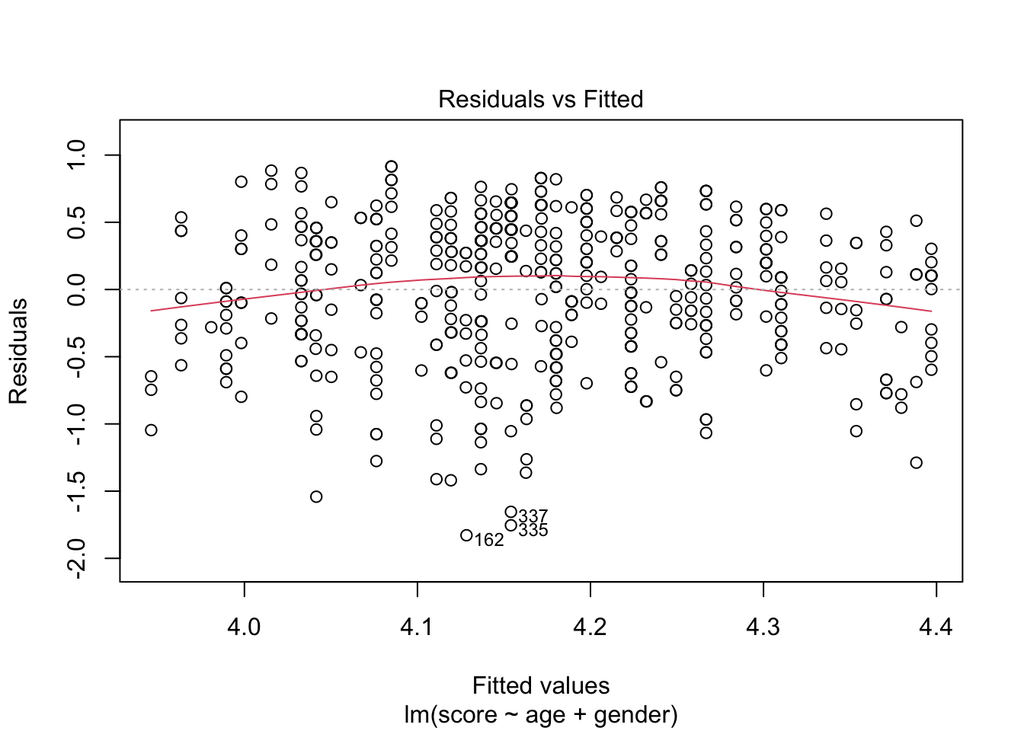

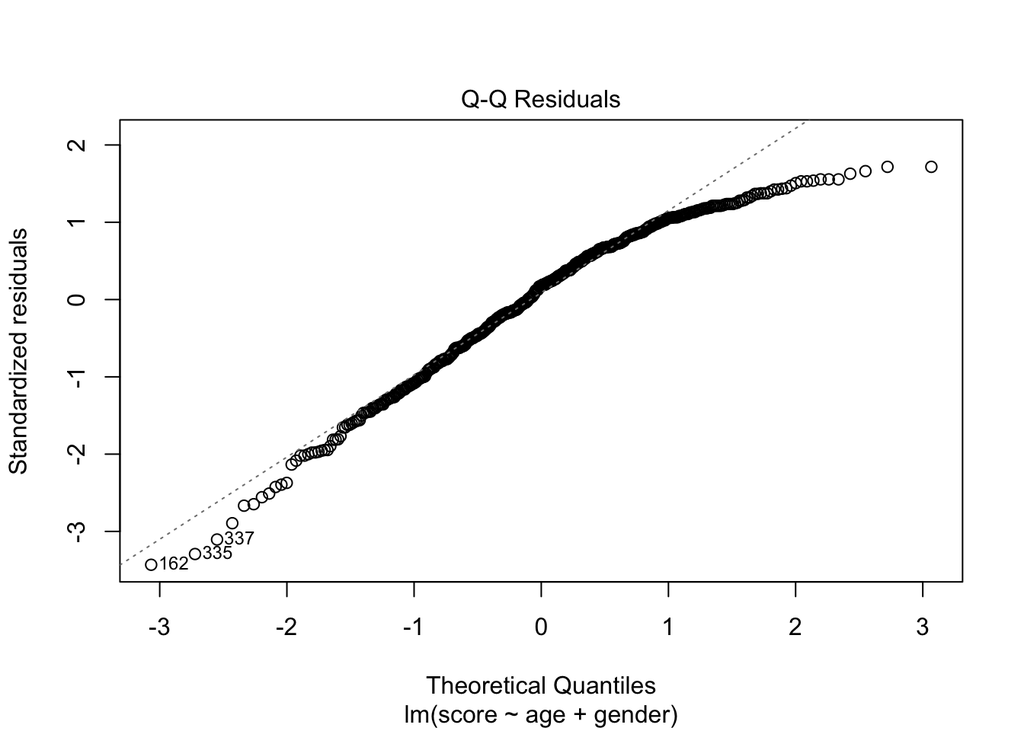

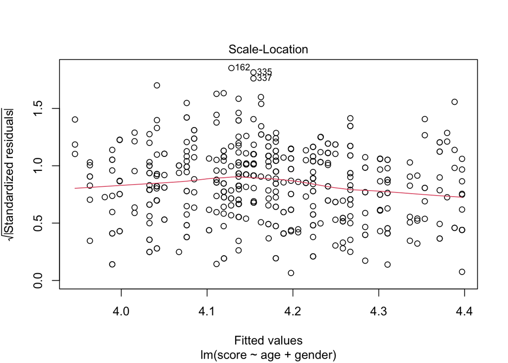

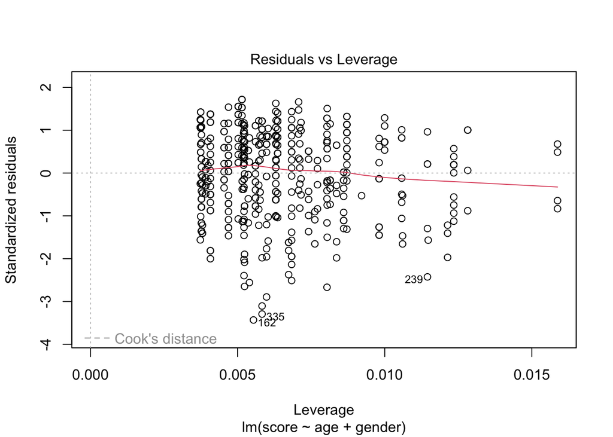

```r
linear_regression_score_age <- lm(score ~ age + gender, data = evals)
plot(linear_regression_score_age)
```

```r
summary(linear_regression_score_age)
```

```
Call:
lm(formula = score ~ age + gender, data = evals)

Residuals:
     Min       1Q   Median       3Q      Max
-1.82833 -0.33494  0.09391  0.42882  0.91506

Coefficients:
             Estimate Std. Error t value Pr(>|t|)
(Intercept)  4.484116   0.125284  35.792  < 2e-16 ***
age         -0.008678   0.002646  -3.280 0.001117 **
gendermale   0.190571   0.052469   3.632 0.000313 ***
---
Signif. codes:  0 '***' 0.001 '**' 0.01 '*' 0.05 '.' 0.1 ' ' 1

Residual standard error: 0.5343 on 460 degrees of freedom
Multiple R-squared:  0.03901,   Adjusted R-squared:  0.03484
F-statistic: 9.338 on 2 and 460 DF,  p-value: 0.0001059
```

The coefficient for age is approximately -0.00868 The coefficient for gender (male) is approximately 0.19057 Since age and gender cannot be zero in practice, the interpretation of the intercept may not be practically meaningful.